# Geog533 Lab 7 - Correlation

## Question 5

This is Exercise 7 in Chapter 7 of the Textbook [R].

### Problem

For the following ranked data, find Spearman’s r, and then test the null hypothesis (using a Type I error probability of 0.10) that the true correlation is equal to zero.

```r
library(knitr)
obs <- 1:6
x <- c(1,2,5,6,11,12)
y <- c(8,4,12,3,10,7)
df <- data.frame(obs,x,y)
names(df) <- c("Observation","Rank of x","Rank of y")
kable(df)
```

| Observation | Rank of x | Rank of y |
| --- | --- | --- |
| 1 | 1 | 8 |
| 2 | 2 | 4 |
| 3 | 5 | 12 |
| 4 | 6 | 3 |
| 5 | 11 | 10 |
| 6 | 12 | 7 |

### Solution

```r
x <- c(1,2,5,6,11,12)
y <- c(8,4,12,3,10,7)
result5 <- cor.test(x,y,method = "spearman",conf.level = .9)
result5
```

```
    Spearman's rank correlation rho

data:  x and y
S = 36, p-value = 1
alternative hypothesis: true rho is not equal to 0
sample estimates:
        rho
-0.02857143
```

```r
if(result5$p.value > 0.05){
  print("we can't reject non hypothesis")
} else{
  print("we reject non hypothesis")
}
```

```
[1] "we can't reject non hypothesis"
```

```r
## correlation coefficient is equal to zero,not signifcant
## there are no correlation with these two data
```

## Question 6

This is Exercise 8 in Chapter 7 of the Textbook [R].

### Problem

Find Pearson’s r for the following data, and then test the null hypothesis that the correlation coefficient is equal to zero. Use a Type I error probability of 0.05.

```r
library(knitr)
obs <- 1:6
x <- c(3.2,2.4,1.6,8.3,7.2,5.1)
y <- c(6.2,7.3,8.1,2.6,6.3,4.3)
df <- data.frame(obs,x,y)
names(df) <- c("Observation","x","y")
kable(df)
```

| Observation | x | y |
| --- | --- | --- |
| 1 | 3.2 | 6.2 |
| 2 | 2.4 | 7.3 |
| 3 | 1.6 | 8.1 |
| 4 | 8.3 | 2.6 |
| 5 | 7.2 | 6.3 |
| 6 | 5.1 | 4.3 |

### Solution

```r
x <- c(3.2,2.4,1.6,8.3,7.2,5.1)
y <- c(6.2,7.3,8.1,2.6,6.3,4.3)
result6 <- cor.test(x,y)
result6
```

```
    Pearson's product-moment correlation

data:  x and y
t = -2.7364, df = 4, p-value = 0.0521
alternative hypothesis: true correlation is not equal to 0
95 percent confidence interval:
 -0.97806755  0.01221668
sample estimates:
       cor
-0.8073491
```

```r
if(result6$p.value > 0.05){
  print("we can't reject non hypothesis")
} else{
  print("we reject non hypothesis")
}
```

```
[1] "we can't reject non hypothesis"
```

```r
## correlation coefficient is equal to zero,not signifcant
## there are no correlation with these two data
```

## Question 7

This is Exercise 9 in Chapter 7 of the Textbook [R].

### Problem

Using R and the Milwaukee dataset, find the correlation between number of bedrooms and lot size.

### Solution

```r
### a
df <- read.csv("https://xujianzi.github.io/data/Bedroom.csv",header = T)
result7 <- cor.test(df$Bdrms,df$Lotsize,alternative = "greater", method = "spearman")
result7
```

```
    Spearman's rank correlation rho

data:  df$Bdrms and df$Lotsize
S = 1.222e+09, p-value < 2.2e-16
alternative hypothesis: true rho is greater than 0
sample estimates:
      rho
0.2239404
```

```r
c_r <- 2/sqrt(nrow(df))
c_r
```

```
[1] 0.04349882
```

```r
if(result7$estimate > c_r && result7$p.value <= 0.05){
  print("rs is significant, we accept alternative hypothesis")
}else{
  print("we can not reject non hypothesis")
}
```

```
[1] "rs is significant, we accept alternative hypothesis"
```

```r
## the bedroom number and lot size have positive correlation.
## the bigger bedroom number is , the larger size the lot has.
```

```r
### b
df1 <- head(df,n = 7)
result7b <- cor.test(df1$Bdrms,df1$Lotsize, method = "spearman")
result7b
```

```
    Spearman's rank correlation rho

data:  df1$Bdrms and df1$Lotsize
S = 90.293, p-value = 0.1438
alternative hypothesis: true rho is not equal to 0
sample estimates:
       rho
-0.6123724
```

```r
c_r1 <- 2/sqrt(7)
c_r1
```

```
[1] 0.7559289
```

```r
if(abs(result7b$estimate)>c_r1){
  print("rs is significant, we accept alternative hypothesis")
}else
  print("rs is not significant, we can not reject non hypothesis")
```

```
[1] "rs is not significant, we can not reject non hypothesis"
```

```r
## the bedroom number and lot size don't have correlation.
```

## Question 8

This is Exercise 10 in Chapter 7 of the Textbook [R].

### Problem

Using R and the Hypothetical UK Housing Prices dataset, find the correlation between floor area and number of bedrooms.

### Solution

```r
df <- read.csv("https://xujianzi.github.io/data/UK.csv",header = T)
result8 <- cor.test(df$bedrooms,df$floorarea,
                    alternative = "greater",method = "spearman")
result8
```

```
    Spearman's rank correlation rho

data:  df$bedrooms and df$floorarea
S = 8274200, p-value < 2.2e-16
alternative hypothesis: true rho is greater than 0
sample estimates:
      rho
0.6004428
```

```r
c_r <- 2/sqrt(nrow(df))
if(result8$estimate > c_r && result8$p.value <= 0.05){
  print("rs is significant, we accept alternative hypothesis")
}else {
  print("we can not reject non hypothesis")
}
```

```
[1] "rs is significant, we accept alternative hypothesis"
```

```r
## the number of bedrooms and floorarea have positive correlation.
## the bigger bedroom number is, the larger floorarea is.
```

## Question 9

Use the **cars** data frame in the **datasets** package to perform the following tasks:

### Problem 9a

Plot a scatterplot for the data frame (x: speed, y: dist)

Solution 9a

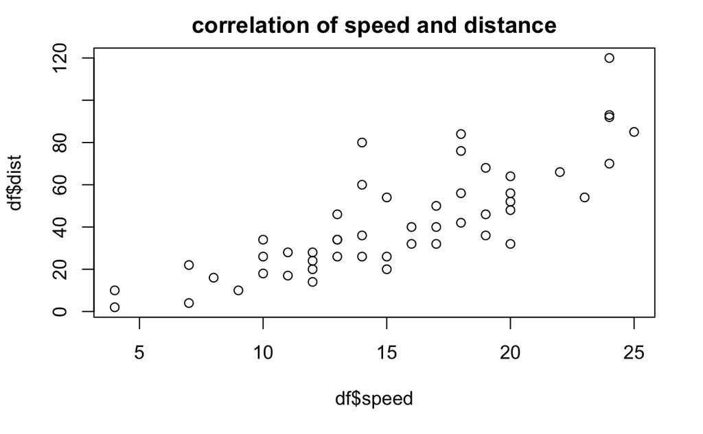

```r
library(datasets)
df <- cars
plot(df$speed,df$dist,main = "correlation of speed and distance")
```

### Problem 9b

How many rows in the data frame?

Solution 9b

```r
nrow(df)
```

```
[1] 50
```

```r
## there are 50 rows in the data frame
```

### Problem 9c

Calculate Pearson’s correlation coefficient using the equation below:
$$r=\frac{\sum_{n}^{i=1}(x_i-\bar{x})(y_i-\bar{y})}{(n-1)s_{x}s_{y}}$$

Solution 9c

```r
df$mspeed <- mean(df$speed)
df$mdist <- mean(df$dist)
df$difs <- df$speed-df$mspeed
df$difd <- df$dist - df$mdist
df$difsd <- df$difs*df$difd
top <- sum(df$difsd)
bot <- sd(df$dist)*sd(df$speed)*(nrow(df)-1)
r <- top/bot
r
```

```
[1] 0.8068949
```

```r
## the correlation coefficient is 0.8068949
```

### Problem 9d

Use the cor.test() function to find Pearson’s correlation coefficient and compare it to the one from part (c)

Solution 9d

```r
result9d <- cor.test(df$speed, df$dist)
result9d
```

```
    Pearson's product-moment correlation

data:  df$speed and df$dist
t = 9.464, df = 48, p-value = 1.49e-12
alternative hypothesis: true correlation is not equal to 0
95 percent confidence interval:
 0.6816422 0.8862036
sample estimates:
      cor
0.8068949
```

```r
if(result9d$estimate == r){
  print("this two outputs are equal")
}
```

```
[1] "this two outputs are equal"
```

### Problem 9e

Calculate Spearman’s rank correlation coefficient using the equation below:
$$r_{S} = 1 - \frac{6\sum_{i=1}^{n}d_{i}^{2}}{n^3-n}$$

Solution 9e

```r
n <- nrow(df)
df$ranksp <- rank(df$speed)
df$rankdi <- rank(df$dist)
df$dif <- df$ranksp - df$rankdi
df$sq_dif <- df$dif^2
top <-sum(df$sq_dif)
rs <- 1- 6*top/(n^3-n)
rs
```

```
[1] 0.8308283
```

### Problem 9f

Use the cor.test() function to find Spearman’s rank correlation coefficient and compare it to the one from part (e)

Solution 9f

```r
result9f <- cor.test(df$speed,df$dist,method = "spearman")
result9f
```

```
    Spearman's rank correlation rho

data:  df$speed and df$dist
S = 3532.8, p-value = 8.825e-14
alternative hypothesis: true rho is not equal to 0
sample estimates:
      rho
0.8303568
```

```r
if(result9f$estimate == rs){
  print("they are equal")
}else
  print("they are not exactly equal")
```

```
[1] "they are not exactly equal"
```

```r
## the manual result and the cor.test result are roughly equal.
```